# Time series analysis

The overall goal of the project is to analyse the stock price of the S&P 500 index fund with two relevant Time Series models. This analysis will primarily focus on predicting or forecasting the potential future stock price of the index fund whilst paying particular attention to the stock market trends with respect to the index fund. The results from such models are extremely useful for investors and hedge funds as it gives them crucial information about the prospects of the index fund. The investors in turn are equipped with the knowledge to make better decisions when investing into the index fund.

The main two Time Series models we will investigate to accomplish this goal are as follows:

- ARIMA model
- SARIMA model

The software required to analyse the S&P 500 stock price with each model will be completed with Python and its data analytics libraries. The general idea of the project is to compare each model once fully built and functional to assess each model's merits.

To begin the project, the dataset obtained for this project will need to be manipulated to comply with the format required for each respective model. The manipulations prepare the data for the Time Series models. The main steps taken to prepare the data are as follows:

1. Loading the dataset
2. Visualising the dataset
3. Preparing the data for the model

## Loading the dataset

Firstly, we will load the *'SaP_500_3yrs_Monthly.csv'* file as a DataFrame (*'SP_500'*), which contains our entire dataset.

Then we will print the first 20 entries in our dataset.

```python
# Importing the pandas library
import pandas as pd

# Loads the 'SaP_500_3yrs_Monthly.csv' which contains our dataset
SP_500 = pd.read_csv('SaP_500_3yrs_Monthly.csv')

# Prints the first 20 entries from our dataset
SP_500.head(20)
```

|  | Date | Open | High | Low | Close |
| --- | --- | --- | --- | --- | --- |
| 0 | 11/2021 | 4610.62 | 4663.46 | 4595.06 | 4660.57 |
| 1 | 10/2021 | 4317.16 | 4608.08 | 4278.94 | 4605.38 |
| 2 | 09/2021 | 4528.80 | 4545.85 | 4305.91 | 4307.54 |
| 3 | 08/2021 | 4406.86 | 4537.36 | 4367.73 | 4522.68 |
| 4 | 07/2021 | 4300.73 | 4429.97 | 4233.13 | 4395.26 |
| 5 | 06/2021 | 4216.52 | 4302.43 | 4164.40 | 4297.50 |
| 6 | 05/2021 | 4191.98 | 4238.04 | 4056.88 | 4204.11 |
| 7 | 04/2021 | 3992.78 | 4218.78 | 3992.78 | 4181.17 |
| 8 | 03/2021 | 3842.51 | 3994.41 | 3723.34 | 3972.89 |
| 9 | 02/2021 | 3731.17 | 3950.43 | 3725.62 | 3811.15 |
| 10 | 01/2021 | 3764.61 | 3870.90 | 3662.71 | 3714.24 |
| 11 | 12/2020 | 3645.87 | 3760.20 | 3633.40 | 3756.07 |
| 12 | 11/2020 | 3336.25 | 3645.99 | 3336.25 | 3621.63 |
| 13 | 10/2020 | 3385.87 | 3549.85 | 3233.94 | 3269.96 |
| 14 | 09/2020 | 3507.44 | 3588.11 | 3209.45 | 3363.00 |
| 15 | 08/2020 | 3288.26 | 3514.77 | 3284.53 | 3500.31 |
| 16 | 07/2020 | 3105.92 | 3279.99 | 3101.17 | 3271.12 |
| 17 | 06/2020 | 3038.78 | 3233.13 | 2965.66 | 3100.29 |
| 18 | 05/2020 | 2869.09 | 3068.67 | 2766.64 | 3044.31 |
| 19 | 04/2020 | 2498.08 | 2954.86 | 2447.49 | 2912.43 |

As we can see the dataset begins at the most current value of the S&P price which is not ideal for the ARIMA model. Therefore we will have to reverse the order of the data to make it usable.

Below, we will remove all the columns in the *'SP_500'* DataFrame except the *'Close'* column which is necessary for implementing the ARIMA model.

```python
## Remove all the columns in 'SP_500' DataFrame except
## the 'Close' column  which is useful for plotting the data
SP_500_Close = SP_500[['Close']].dropna()
```

## Visualising the dataset

We will plot the dataset so we can plan our approach for the Time series problem.

In order to plot out S&P 500 dataset we need to:

- Create a new DataFrame containing only the *'Date'* and *'Close'* Variables.
- Create a DataFrame containing only the *'Close'* variable and reverse the order of the variable.
- Create a seperate DataFrame containing only the *'Date'* variable and reverse the order of the variable.
- Convert the *'Date'* DataFrame to datetime
- Plot the final updated variables using matplotlib

Creating a new DataFrame for plotting the S&P 500 dataset purposes only containing the *'Date'* and *'Close'* Variables as it won't affect the original dataset.

We will separate the *'Close'* variable with the DataFrame *'Plotting_SP_500_Profit'* containing all the closing day prices in our dataset. The order of the *'Close'* prices are reversed since our dataset is in the opposite order for our plot.

We will then separate the *'Date'* variables with a unique DataFrame to convert the variable to datetime which is needed for the *'autofmt_xdate()'* function used to make the plot more readable. The order of the *'Date'* will also need to be reversed to match the prices from above.

Finally we can plot the complete dataset with the updated variables to observe the monthly price of the S&P 500 from *'03/2018'* to *'11/2021'*.

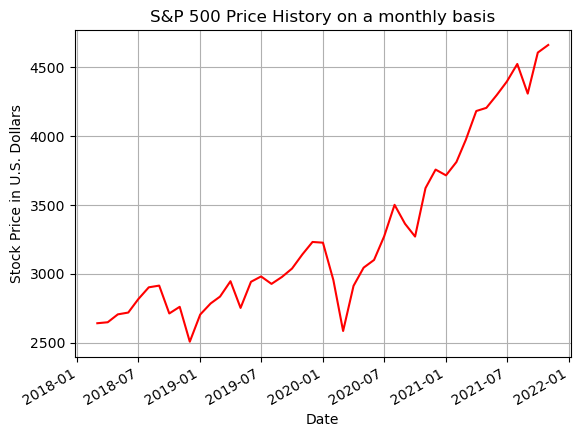

```python
from matplotlib import pyplot as plt

## Creates a new Dataframe using only the 'Date' and 'Close' variables
Plotting_SP_500 = pd.DataFrame(SP_500, columns = ['Date', 'Close'])

## Creates a Variable 'Plotting_SP_500_Profit' which contains all
## the closing day prices in our dataset.
Plotting_SP_500_Profit = SP_500.iloc[:, -1].values
Plotting_SP_500_Profit = Plotting_SP_500_Profit[::-1]

## Creates a Variable 'Plotting_SP_500_Date' which contains all the
## dates associated with the closing price in the
## 'Plotting_SP_500_Profit' variable created above.
Plotting_SP_500_Date = SP_500.iloc[:, 0].values
Plotting_SP_500_Date = Plotting_SP_500_Date[::-1]

## Converts the content in the 'Plotting_SP_500_Date' variable to
## datetime. This is needed for the 'autofmt_xdate()' function
## used to make the plot of the dataset more readable.
Plotting_SP_500_Date = pd.to_datetime(Plotting_SP_500_Date)

## Creates a new Dateframe to store only the content needed to
## plot the dataset.
Plot_for_SP_500 = pd.DataFrame(Plotting_SP_500_Profit, Plotting_SP_500_Date)

## Uses 'matplotlib' library to plot the dataset
plt.title('S&P 500 Price History on a monthly basis')
plt.xlabel('Date')
plt.ylabel('Stock Price in U.S. Dollars')
plt.grid(True)
plt.plot(Plot_for_SP_500, color = 'red')
plt.gcf().autofmt_xdate()

plt.show()
```

## Model 1: ARIMA model

The first model we are going to test for this problem is an ARIMA (AutoRegressive Integrated Moving Average) model, which is a forecasting algorithm based on the idea that the information in the past values of the time series can alone be used to predict the future values.

Notation for the ARIMA model: $\text{ARIMA}(p,d,q)$

The equation for the ARIMA model:

$$Y_t = c + \beta_1{Y_{t-1}} + \beta_2{Y_{t-2}} + ... + \beta_p{Y_{t-p}} + \theta_1{\epsilon_{t-1}} + ... + \theta_q{\epsilon_{t-q}} + {\epsilon_t}$$$$\text{where}$$$$c \text{ is the intercept}$$$$\text{and}$$$$\beta_1{Y_{t-1}} + \beta_2{Y_{t-2}} + ... + \beta_p{Y_{t-p}} \text{ are the lags (AR)}$$$$\text{and}$$$$\theta_1{\epsilon_{t-1}} + ... + \theta_q{\epsilon_{t-q}} + {\epsilon_t} \text{ are the errors (MA)}$$

In basic terms we can look at the formula as:

$$ \text{Predicted } {Y_t} = Constant + \text{Linear combination Lags of Y upto p lags} + \text{Linear Combination of Lagged forecast error upto q lags} $$

We will begin building the ARIMA model by checking if the Time Series is stationary and subsequently determining the *d* term for the model.

### Checking if the Time Series is stationary

It's firstly important to check if the time series is stationary.

This can be done using the '*adfuller*' function from the '*statsmodels*' library which performs the Augmented Dickey-Fuller (ADF) test on the S&P 500 Closing prices to show the presence of serial correlation in our time series. With Time Series data, this test generally proves that the time series is non-stationary.

In order to perform an ADF test on our model, we need to first create a new variable *'SP_500_Close_Values'* which will contain the entire dataset. Then we will isolate and invert the *'Close'* column from said dataset which is all that is needed for the ARIMA model. This column will contain all the closing prices of the S&P 500 on a monthly basis from *'03/2018'* to *'11/2021'*.

The data from the dataset isn't in the correct format for the ARIMA model, therefore we will have to alter the data to suit our needs. These alteration will include:

- Creating a new variable *'SP_500_Close_Values'* to contain all the prices of S&P 500.
- Reversing the order of the variable to make the data usable
- Resetting the *'index'* column to ensure that our plot is in the correct order

In our case, if the p-value > 0.05 meaning the time series is definitely Non-Stationary.

```python
## Importing the 'adfuller' function from the 'statesmodels' library
from statsmodels.tsa.stattools import adfuller

## Creates a Variable 'SP_500_Close_Values' which contains all
## the content from the 'SP_500_Close' Variable and fit to our plot.
SP_500_Close_Values = SP_500_Close
Reverse_SP_500_Close_Values = SP_500_Close_Values[::-1]
Reverse_SP_500_Close_Values.reset_index(inplace=True, drop=True)

## Uses the 'adfuller' function to check if the time series
## is stationary or not
result = adfuller(Reverse_SP_500_Close_Values.dropna())

print('ADF Statistic:   ', result[0])
print('p-value:         ', result[1])
```

```
ADF Statistic:    0.3802555084426436
p-value:          0.9807413629845056
```

Our p-value is 0.98 so it is clear that this price series is non-stationary. This isn't a problem since we could have probably guessed that the time in which the stock prices were collected will influence future results.

In order to make the ARIMA model work for this time series we need to difference them to remove the trends in the time series. It might take multiple differences to remove the influence of trends in the time series. The goal of this method is to make the time series stationary. The amount of differences required is known as the order of differencing (d).

### Determine *d* - the number of differencing required to make the time series stationary

We can use the *'plot_acf'* function from *'statsmodels'* and the acf plot tells us how many terms are required to remove any autocorrelation in the series.

#### Autocorrelation Function (ACF)

Autocorrelation refers to the correlation between a Time series and a previous version of the time series.

For this dataset, we shifted the time series back by one month. This shift is known as the lag.

The *'statsmodels'* library has a function *'plot_act'* to plot the autocorrelation for our time series data. This function plots the lags on the horizontal axis and the correlations on the vertical axis.

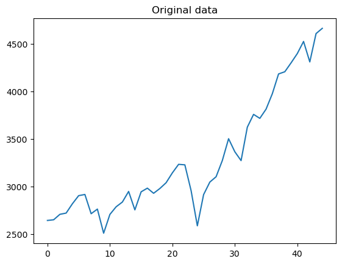

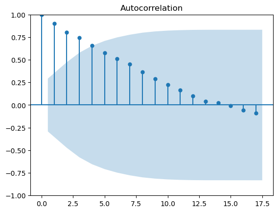

```python
from statsmodels.graphics.tsaplots import plot_acf

## Plots the autocorrelation for the closing prices of the S&P 500
## in our dataset
plt.plot(Reverse_SP_500_Close_Values)
plt.title('Original data')
plot_acf(Reverse_SP_500_Close_Values)
plt.show()
```

$$ \text{First-order differencing: } x'_t = x_t x_{t -1} $$

Next, we will plot the difference of the closing price data along with the autocorrelation of the difference for the closing prices of the S&P 500 in our dataset

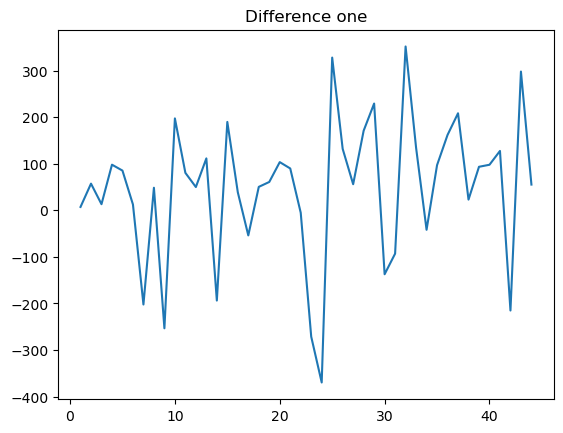

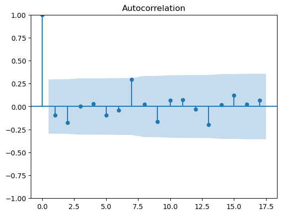

```python
## Calculates the difference of the closing price data
diff = Reverse_SP_500_Close_Values.diff().dropna()

## Plots the difference of the closing price data along with
## the autocorrelation of the difference for the closing prices
## of the S&P 500 in our dataset
plt.plot(diff)
plt.title('Difference one')
plot_acf(diff)
plt.show()
```

$$ \text{Second-order differencing: } x_t* = x'_t - x'_{t -1} $$$$ = (x_t - x_{t-1}) - (x_{t-1} - x_{t-2}) $$$$ = x_t - 2x_{t-1} + x_{t-2} $$

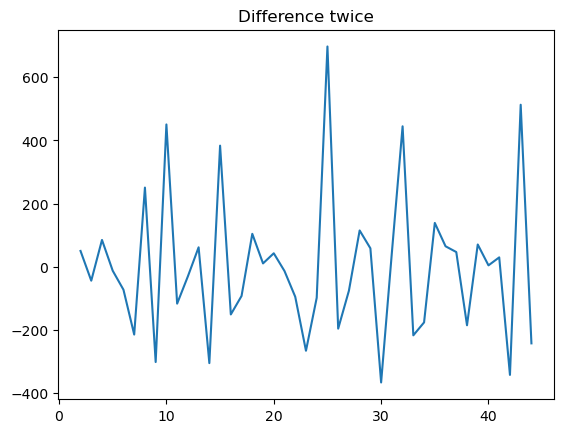

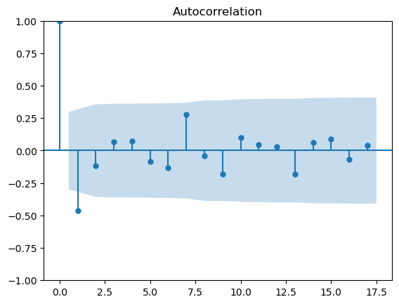

```python
## Calculates the difference of the difference of the closing price data
diff = Reverse_SP_500_Close_Values.diff().diff().dropna()

## Plots the second difference of the closing price data along with
## the autocorrelation of the difference for the closing prices
## of the S&P 500 in our dataset
plt.plot(diff)
plt.title("Difference twice")
## Add ; to the end of the plot function so that the plot is not
## duplicated
plot_acf(diff);
plt.show()
```

Lag terms in the graph skew to the lag axis when the series is differenced twice indicating that the series is over-differenced. So, we will set the *d* term as 1.

Our order of differencing term (d) = 1

The *d* term will also be confirmed below with the function *'pmdarima.arima.ndiffs'*:

```python
## Estimates the ARIMA differencing term d required to make the time
## series stationary
from pmdarima.arima.utils import ndiffs

print("Estimate ARIMA differencing term, d, required to convert the time series to stationary below:")
ndiffs(Reverse_SP_500_Close_Values, test="adf")
```

```
Estimate ARIMA differencing term, d, required to convert the time series to stationary below:
```

```
1
```

Since we came to the same conclusion, we can be reasonably confident in our result.

### Determining *p* - the order of the AR term

p is the order of the Auto Regressive (AR) term. It refers to the number of lags to be used as predictors.

We can find out the required number of AR terms by inspecting the Partial Autocorrelation (PACF) plot.

The partial autocorrelation represents the correlation between the series and its lags.

```python
from statsmodels.graphics.tsaplots import plot_pacf
```

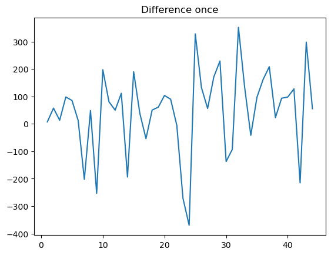

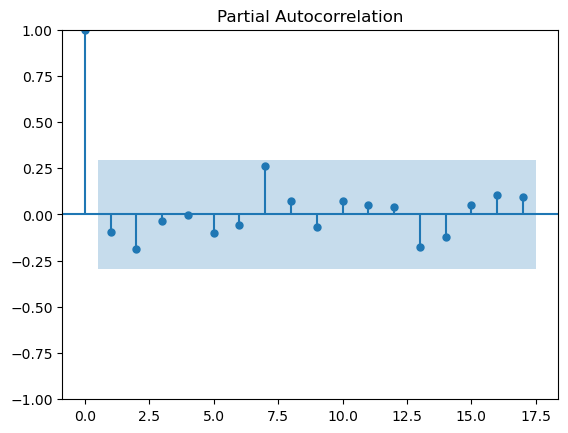

```python
diff = Reverse_SP_500_Close_Values.diff().dropna()

plt.plot(diff)
plt.title('Difference once')
plot_pacf(diff)
plt.show()
```

### Determining *q* - the order of the MA term

The *q* term is the order of the Moving Average(MA), which refers to the number of lagged forecast errors that should go in the ARIMA model.

We can look at the ACF plot for the number of MA terms.

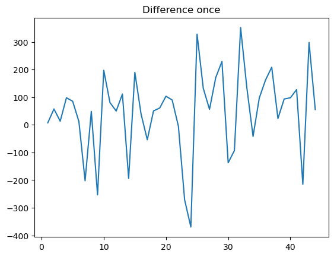

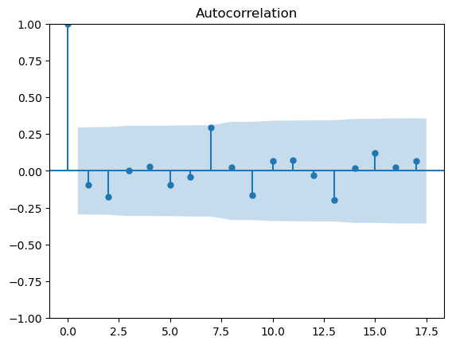

```python
diff = Reverse_SP_500_Close_Values.diff().dropna()

plt.plot(diff)
plt.title("Difference once")
plot_acf(diff);
plt.show()
```

We choose a forecast of 0 due to the fact that no lag is over the significant level

### Fitting the ARIMA model

ARIMA (p,d,q)

p = 7 d = 1 q = 0

$$\text{ARIMA}(7,1,0)$$

The model is prepared on the training data by calling the *fit()* function.

```python
from statsmodels.tsa.arima.model import ARIMA

import warnings
warnings.filterwarnings('ignore')     # Ignore unnecessary warnings

# ARIMA Model
model = ARIMA(Reverse_SP_500_Close_Values, order=(7, 1, 0))
result = model.fit()
result.summary()
```

SARIMAX Results

| Dep. Variable: | Close | No. Observations: | 45 |
| --- | --- | --- | --- |
| Model: | ARIMA(7, 1, 0) | Log Likelihood | -282.727 |
| Date: | Tue, 05 Mar 2024 | AIC | 581.454 |
| Time: | 18:53:26 | BIC | 595.727 |
| Sample: | 0 | HQIC | 586.747 |
|  | - 45 |  |  |
| Covariance Type: | opg |  |  |

|  | coef | std err | z | P>\|z\| | [0.025 | 0.975] |
| --- | --- | --- | --- | --- | --- | --- |
| ar.L1 | -0.0203 | 0.127 | -0.159 | 0.873 | -0.270 | 0.229 |
| ar.L2 | -0.0822 | 0.172 | -0.478 | 0.633 | -0.419 | 0.255 |
| ar.L3 | 0.0520 | 0.201 | 0.259 | 0.796 | -0.342 | 0.446 |
| ar.L4 | 0.0693 | 0.165 | 0.421 | 0.673 | -0.253 | 0.392 |
| ar.L5 | 0.0329 | 0.146 | 0.225 | 0.822 | -0.253 | 0.319 |
| ar.L6 | 0.0281 | 0.199 | 0.141 | 0.888 | -0.362 | 0.418 |
| ar.L7 | 0.3403 | 0.213 | 1.601 | 0.109 | -0.076 | 0.757 |
| sigma2 | 2.167e+04 | 5038.427 | 4.301 | 0.000 | 1.18e+04 | 3.15e+04 |

| Ljung-Box (L1) (Q): | 0.30 | Jarque-Bera (JB): | 6.52 |
| --- | --- | --- | --- |
| Prob(Q): | 0.59 | Prob(JB): | 0.04 |
| Heteroskedasticity (H): | 0.99 | Skew: | -0.88 |
| Prob(H) (two-sided): | 0.99 | Kurtosis: | 3.67 |

Warnings:  
[1] Covariance matrix calculated using the outer product of gradients (complex-step).

The model summary gives us a lot of information about our ARIMA model. The important areas of focus from the summary:

- Values of the coefficients

The *'residuals'* in a time series model are what is left over after fitting a model.

The residual errors of a time series model are equal to the difference between the expected values and the predicted values.

Plot the residual errors to ensure there are no patterns (that is, looking for constant mean and variance).

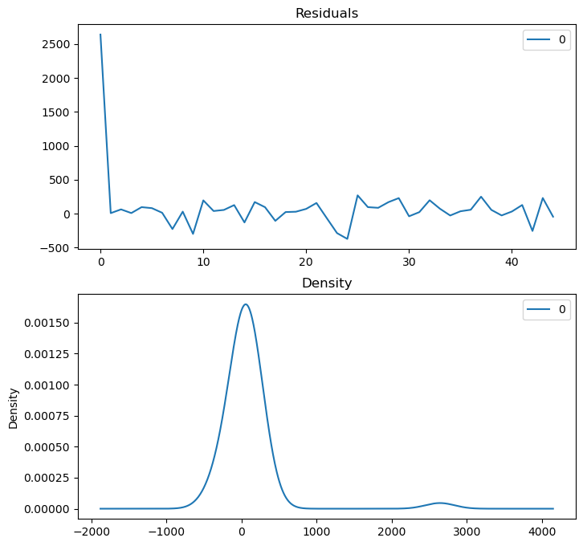

```python
# Plot residual errors
residuals = pd.DataFrame(result.resid)

fig, (ax1, ax2) = plt.subplots(2, 1, figsize=(8, 8))

residuals.plot(title = 'Residuals', ax=ax1)
residuals.plot(kind='kde', title = 'Density', ax=ax2)
plt.show()
```

The residual errors seem reasonably fine with a near zero mean and uniform variance.

Now, let's plot the actual values against the predicted values using the *'plot_predict()'*.

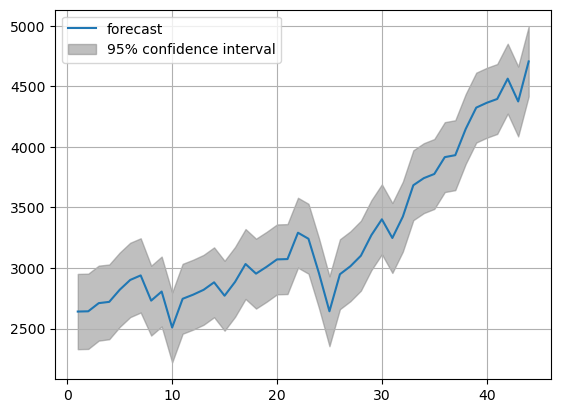

```python
from statsmodels.graphics.tsaplots import plot_predict

# Actual values vs Predicted values
result = plot_predict( result,
    start=1, end=44, dynamic=False,
)


plt.grid(True)
plt.show()
```

Creating a train and test set to use the ARIMA model:

- The train set will contain 87.5% of our data
- The test set will then contain the remaining 12.5% of the data

```python
## 'n' is an integer that is the equivalent to 87.5% of the
## amount of closing prices from our dataset
n = int(len(Reverse_SP_500_Close_Values) * 0.875)
## Our training set contains the first 87.5% of closing prices
## from our dataset
train = Reverse_SP_500_Close_Values[:n]
## Our testing set will contain the remainder of closing prices
## from our dataset
test = Reverse_SP_500_Close_Values[n:]
```

```python
print('Number of closing prices in our training set:    ', len(train))
print('Number of closing prices in our testing set:     ', len(test))
```

```
Number of closing prices in our training set:     39
Number of closing prices in our testing set:      6
```

We will plot the training vs testing data from the S&P 500 closing price data.

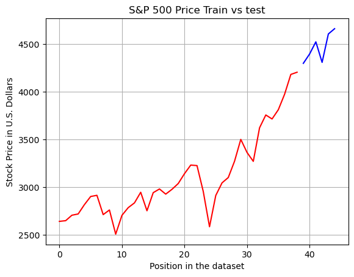

```python
## Plots the training vs testing data from the S&P 500 data
plt.title('S&P 500 Price Train vs test')
plt.xlabel('Position in the dataset')
plt.ylabel('Stock Price in U.S. Dollars')
plt.grid(True)
plt.plot(train, color = 'red')
plt.plot(test, color = 'blue')

plt.show()
```

```python
model = ARIMA(train, order=(7, 1, 0))
result = model.fit()
print(result.summary())
```

```
                               SARIMAX Results
==============================================================================
Dep. Variable:                  Close   No. Observations:                   39
Model:                 ARIMA(7, 1, 0)   Log Likelihood                -243.794
Date:                Tue, 05 Mar 2024   AIC                            503.589
Time:                        18:53:33   BIC                            516.690
Sample:                             0   HQIC                           508.250
                                 - 39
Covariance Type:                  opg
==============================================================================
                 coef    std err          z      P>|z|      [0.025      0.975]
------------------------------------------------------------------------------
ar.L1          0.0675      0.141      0.481      0.631      -0.208       0.343
ar.L2         -0.1211      0.197     -0.614      0.539      -0.508       0.266
ar.L3          0.0769      0.211      0.364      0.716      -0.337       0.491
ar.L4          0.0116      0.186      0.062      0.950      -0.354       0.377
ar.L5          0.0651      0.153      0.424      0.671      -0.236       0.366
ar.L6          0.0008      0.242      0.003      0.997      -0.473       0.475
ar.L7          0.3553      0.225      1.582      0.114      -0.085       0.795
sigma2      2.108e+04   5118.070      4.119      0.000     1.1e+04    3.11e+04
===================================================================================
Ljung-Box (L1) (Q):                   0.08   Jarque-Bera (JB):                 5.23
Prob(Q):                              0.78   Prob(JB):                         0.07
Heteroskedasticity (H):               0.89   Skew:                            -0.82
Prob(H) (two-sided):                  0.84   Kurtosis:                         3.79
===================================================================================

Warnings:
[1] Covariance matrix calculated using the outer product of gradients (complex-step).
```

```python
step = 6

# Forecast future values using our ARIMA model with the '.forecast' function.
fc = result.forecast(step, alpha=0.05) # 95% confidence interval
## Removed se and conf variables
```

```python
## Make a pandas series to store the forecasted values
fc = pd.Series(fc, index=test[:step].index)

## Make as separate pandas series to store the upper and lower confidence levels
#lower = pd.Series(conf[:, 0], index=test[:step].index)
#upper = pd.Series(conf[:, 1], index=test[:step].index)
```

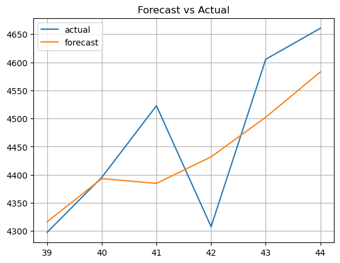

```python
plt.plot(test[:step], label="actual")
plt.plot(fc, label="forecast")
#plt.fill_between(lower.index, lower, upper, color="k", alpha=0.1)
plt.title("Forecast vs Actual")
plt.legend(loc="upper left")
plt.grid(True)
plt.show()
```

```python
answer = pd.DataFrame({'Actual Price' :test['Close'], 'Forecasted Price' :fc, 'Difference' :test['Close']-fc})
answer
```

|  | Actual Price | Forecasted Price | Difference |
| --- | --- | --- | --- |
| 39 | 4297.50 | 4316.327244 | -18.827244 |
| 40 | 4395.26 | 4393.059553 | 2.200447 |
| 41 | 4522.68 | 4384.579177 | 138.100823 |
| 42 | 4307.54 | 4431.735922 | -124.195922 |
| 43 | 4605.38 | 4502.277364 | 103.102636 |
| 44 | 4660.57 | 4582.882860 | 77.687140 |

```python
from math import sqrt
import numpy as np

# Calculate the Mean Absolute Percentage Error
mape = np.mean(np.abs(fc - test['Close'])/np.abs(test['Close']))
print('Test MAPE:                    ', mape)
print('Overall Accuracy Percentage:  ', (1 - mape)*100)
```

```
Test MAPE:                     0.017217576819564814
Overall Accuracy Percentage:   98.27824231804352
```

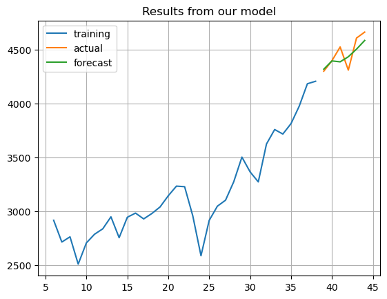

```python
plt.plot(train[step:], label='training')
plt.plot(test[:step], label='actual')
plt.plot(fc, label='forecast')
#plt.fill_between(lower.index, lower, upper, color='k', alpha=0.1)
plt.title('Results from our model')
plt.legend(loc='upper left')
plt.grid(True)
plt.show()
```

## Model 2: SARIMA

The second model we will be testing is a SARIMA model.

Seasonal Autoregressive Integrated Moving Average (SARIMA) model builds upon the ARIMA model. It is formed by including additional seasonal terms (*P*, *D*, *Q*, *m*) to the ARIMA model. It can be denoted as follows:

[figure not shown]

A SARIMA model is characterised by 4 additional terms (*P*, *D*, *Q*, *m*):

- *P* is the order of the seasonal AR term.
- *D* is the number of seasonal differencing referring to the I term.
- *Q* is the order of the seasonal MA term.
- *m* is the number of time steps for a single seasonal period.

To begin, we will load the *'SaP_500_3yrs_Monthly.csv'* file as a new DataFrame (*'data'*) to remove any influence from our ARIMA model built earlier. In this DataFrame, we will use the *'Date'* column as the index for the DataFrame.

We will then remove all the columns in the *'data'* DataFrame except the *'Close'* column which is linked to the correct dates since the *'Date'* is the index for the DataFrame

```python
## We will load the 'SaP_500_3yrs_Monthly.csv' file as a new DataFrame ('data')
## to remove any influence from our ARIMA model built earlier using the 'Date'
## column as the index for the DataFrame
data = pd.read_csv('SaP_500_3yrs_Monthly.csv', parse_dates=['Date'], index_col='Date')

## Removes all the columns in the 'data' DataFrame except the
## 'Close' column which is linked to the correct dates since the
## 'Date' is the index for the DataFrame
data = data[['Close']].dropna()
data = data[::-1]
```

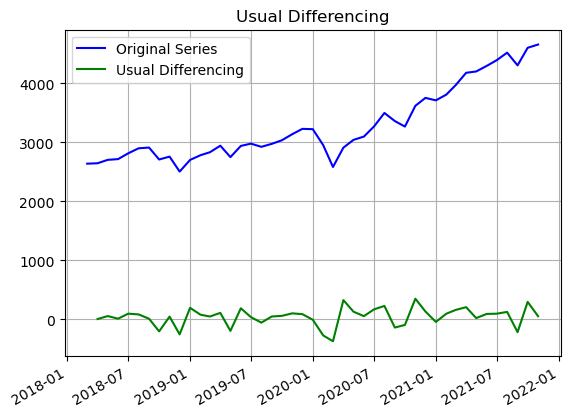

```python
plt.plot(data, label='Original Series', color = 'blue')
plt.plot(data.diff(1), label='Usual Differencing', color = 'green')
plt.title('Usual Differencing')
plt.legend(loc='upper left', fontsize=10)
plt.grid(True)
plt.gcf().autofmt_xdate()

plt.show()
```

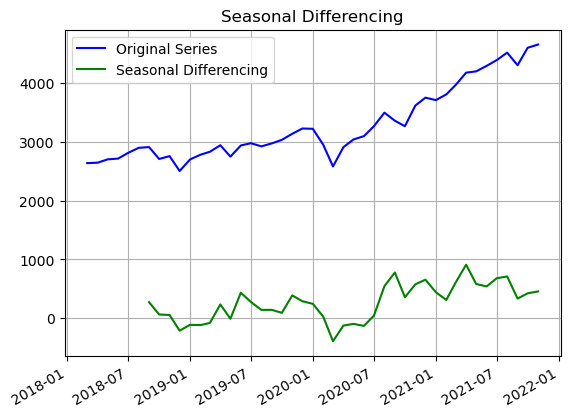

```python
plt.plot(data, label='Original Series', color = 'blue')
plt.plot(data.diff(6), label='Seasonal Differencing', color = 'green')
plt.title('Seasonal Differencing')
plt.legend(loc='upper left', fontsize=10)
plt.grid(True)
plt.gcf().autofmt_xdate()

plt.show()
```

```python
import pmdarima as pm

# Seasonal - fit stepwise auto-ARIMA
smodel = pm.auto_arima(data['Close'], start_p=1, start_q=1,
                         test='adf',
                         max_p=6, max_q=6, m=6,
                         start_P=0, seasonal=True,
                         d=None, D=1, trace=True,
                         error_action='ignore',
                         suppress_warnings=True,
                         stepwise=True)

smodel.summary()
```

```
Performing stepwise search to minimize aic
 ARIMA(1,2,1)(0,1,1)[6]             : AIC=inf, Time=0.13 sec
 ARIMA(0,2,0)(0,1,0)[6]             : AIC=541.383, Time=0.01 sec
 ARIMA(1,2,0)(1,1,0)[6]             : AIC=525.631, Time=0.05 sec
 ARIMA(0,2,1)(0,1,1)[6]             : AIC=inf, Time=0.07 sec
 ARIMA(1,2,0)(0,1,0)[6]             : AIC=534.313, Time=0.03 sec
 ARIMA(1,2,0)(2,1,0)[6]             : AIC=522.905, Time=0.10 sec
 ARIMA(1,2,0)(2,1,1)[6]             : AIC=521.582, Time=0.35 sec
 ARIMA(1,2,0)(1,1,1)[6]             : AIC=inf, Time=0.16 sec
 ARIMA(1,2,0)(2,1,2)[6]             : AIC=inf, Time=0.42 sec
 ARIMA(1,2,0)(1,1,2)[6]             : AIC=inf, Time=0.47 sec
 ARIMA(0,2,0)(2,1,1)[6]             : AIC=528.076, Time=0.20 sec
 ARIMA(2,2,0)(2,1,1)[6]             : AIC=517.548, Time=0.37 sec
 ARIMA(2,2,0)(1,1,1)[6]             : AIC=515.665, Time=0.16 sec
 ARIMA(2,2,0)(0,1,1)[6]             : AIC=513.666, Time=0.09 sec
 ARIMA(2,2,0)(0,1,0)[6]             : AIC=525.673, Time=0.04 sec
 ARIMA(2,2,0)(0,1,2)[6]             : AIC=515.665, Time=0.22 sec
 ARIMA(2,2,0)(1,1,0)[6]             : AIC=517.997, Time=0.06 sec
 ARIMA(2,2,0)(1,1,2)[6]             : AIC=inf, Time=0.55 sec
 ARIMA(1,2,0)(0,1,1)[6]             : AIC=inf, Time=0.06 sec
 ARIMA(3,2,0)(0,1,1)[6]             : AIC=511.883, Time=0.14 sec
 ARIMA(3,2,0)(0,1,0)[6]             : AIC=523.425, Time=0.05 sec
 ARIMA(3,2,0)(1,1,1)[6]             : AIC=inf, Time=0.24 sec
 ARIMA(3,2,0)(0,1,2)[6]             : AIC=inf, Time=0.43 sec
 ARIMA(3,2,0)(1,1,0)[6]             : AIC=517.272, Time=0.11 sec
 ARIMA(3,2,0)(1,1,2)[6]             : AIC=515.853, Time=0.56 sec
 ARIMA(4,2,0)(0,1,1)[6]             : AIC=513.455, Time=0.17 sec
 ARIMA(3,2,1)(0,1,1)[6]             : AIC=inf, Time=0.21 sec
 ARIMA(2,2,1)(0,1,1)[6]             : AIC=inf, Time=0.17 sec
 ARIMA(4,2,1)(0,1,1)[6]             : AIC=inf, Time=0.26 sec
 ARIMA(3,2,0)(0,1,1)[6] intercept   : AIC=513.876, Time=0.22 sec

Best model:  ARIMA(3,2,0)(0,1,1)[6]
Total fit time: 6.120 seconds
```

SARIMAX Results

| Dep. Variable: | y | No. Observations: | 45 |
| --- | --- | --- | --- |
| Model: | SARIMAX(3, 2, 0)x(0, 1, [1], 6) | Log Likelihood | -250.942 |
| Date: | Tue, 05 Mar 2024 | AIC | 511.883 |
| Time: | 18:53:48 | BIC | 519.938 |
| Sample: | 03-01-2018 | HQIC | 514.723 |
|  | - 11-01-2021 |  |  |
| Covariance Type: | opg |  |  |

|  | coef | std err | z | P>\|z\| | [0.025 | 0.975] |
| --- | --- | --- | --- | --- | --- | --- |
| ar.L1 | -0.7842 | 0.136 | -5.754 | 0.000 | -1.051 | -0.517 |
| ar.L2 | -0.5947 | 0.156 | -3.804 | 0.000 | -0.901 | -0.288 |
| ar.L3 | -0.3201 | 0.213 | -1.503 | 0.133 | -0.738 | 0.097 |
| ma.S.L6 | -0.8931 | 0.650 | -1.375 | 0.169 | -2.167 | 0.380 |
| sigma2 | 3.437e+04 | 1.83e+04 | 1.874 | 0.061 | -1577.804 | 7.03e+04 |

| Ljung-Box (L1) (Q): | 0.15 | Jarque-Bera (JB): | 0.41 |
| --- | --- | --- | --- |
| Prob(Q): | 0.69 | Prob(JB): | 0.81 |
| Heteroskedasticity (H): | 0.46 | Skew: | -0.01 |
| Prob(H) (two-sided): | 0.19 | Kurtosis: | 2.48 |

Warnings:  
[1] Covariance matrix calculated using the outer product of gradients (complex-step).

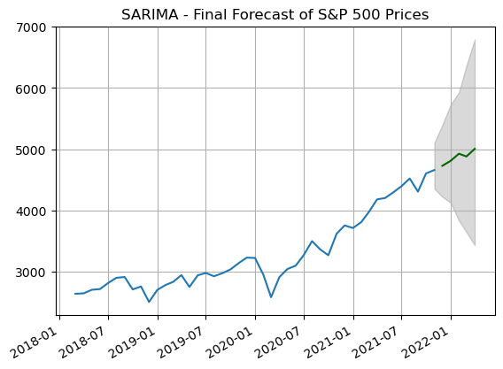

```python
## Plotting the final forecast of the S&P 500 Prices

n_periods = 6   # Forecast for 6 time frequencies (6 months)
fitted, confint = smodel.predict(n_periods=n_periods, return_conf_int=True)
index_of_fc = pd.date_range(data.index[-1], periods = n_periods, freq='MS')

# make series for plotting purpose
fitted_series = pd.Series(fitted, index=index_of_fc)
lower_series = pd.Series(confint[:, 0], index=index_of_fc)
upper_series = pd.Series(confint[:, 1], index=index_of_fc)

## Our Final Result
plt.plot(data)
plt.plot(fitted_series, color='darkgreen')
plt.fill_between(lower_series.index,
                 lower_series,
                 upper_series,
                 color='k', alpha=.15, label='conf int')

plt.title("SARIMA - Final Forecast of S&P 500 Prices")
plt.gcf().autofmt_xdate()
plt.grid(True)
plt.show()
```

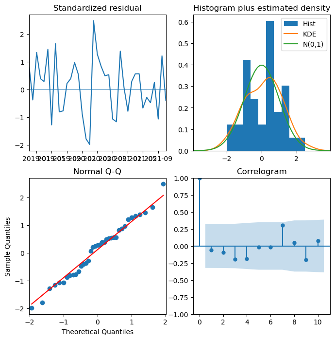

```python
from statsmodels.tsa.arima.model import ARIMAResults

smodel.plot_diagnostics(figsize=(8,8))
plt.show()
```

```python
forecasted_Price = pd.DataFrame({'Forecasted Price' :fitted_series})
forecasted_Price
```

|  | Forecasted Price |
| --- | --- |
| 2021-11-01 | NaN |
| 2021-12-01 | 4729.958218 |
| 2022-01-01 | 4810.806532 |
| 2022-02-01 | 4927.390320 |
| 2022-03-01 | 4882.150932 |
| 2022-04-01 | 5006.821686 |

### Comparing the two models

Each models will be summarised below:

**Model 1: ARIMA model**

The ARIMA model uses the ‘Close’ variable to forecast the future price values of the stock price. It consists of dividing the dataset provided into a training and testing set. The training set is used to train the ARIMA models to calculate the parameters, while the testing set allows us to assess the performance of the model on new and unseen data. This gives instance feedback to how accurate the model is on the price prediction problem.

**Model 2: SARIMA model**

The SARIMA model uses both the ‘Date’ and ‘Close’ variables to predict the future values of the stock price. The model is trained on past data from our dataset in order to forecast future values for the stock price. It takes into account seasonality by adding additional seasonal terms to the model. This new model is extremely useful since it forecasts future prices of the stock price which can be a good indication whether investing in the index fund is a good idea.